# Risk Factor Analysis

## Outcome Variable

**Outcome Variable:** haz

## Predictor Variables

**Intervention Variable:** impfloor

**Adjustment Set:**

- arm
- sex
- W_mage
- meducyrs
- feducyrs
- hhwealth_quart
- hfoodsec
- W_mhtcm
- W_mwtkg
- W_mbmi
- W_nrooms
- W_nchldlt5
- W_parity
- impsan
- safeh20
- delta_W_mage
- delta_meducyrs
- delta_feducyrs
- delta_hhwealth_quart
- delta_hfoodsec
- delta_W_mhtcm
- delta_W_mwtkg
- delta_W_mbmi
- delta_W_nrooms
- delta_W_nchldlt5
- delta_W_parity
- delta_impsan
- delta_safeh20

## Stratifying Variables

The analysis was stratified on these variable(s):

- agecat
- studyid
- country

## Data Summary

| agecat | studyid | country | impfloor | n_cell | n |
| --- | --- | --- | --- | --- | --- |
| Birth | ki0047075b-MAL-ED | BANGLADESH | 1 | 196 | 213 |
| Birth | ki0047075b-MAL-ED | BANGLADESH | 0 | 17 | 213 |
| Birth | ki0047075b-MAL-ED | BRAZIL | 1 | 58 | 60 |
| Birth | ki0047075b-MAL-ED | BRAZIL | 0 | 2 | 60 |
| Birth | ki0047075b-MAL-ED | INDIA | 1 | 35 | 41 |
| Birth | ki0047075b-MAL-ED | INDIA | 0 | 6 | 41 |
| Birth | ki0047075b-MAL-ED | NEPAL | 1 | 9 | 25 |
| Birth | ki0047075b-MAL-ED | NEPAL | 0 | 16 | 25 |
| Birth | ki0047075b-MAL-ED | PERU | 1 | 39 | 215 |
| Birth | ki0047075b-MAL-ED | PERU | 0 | 176 | 215 |
| Birth | ki0047075b-MAL-ED | SOUTH AFRICA | 1 | 87 | 96 |
| Birth | ki0047075b-MAL-ED | SOUTH AFRICA | 0 | 9 | 96 |
| Birth | ki0047075b-MAL-ED | TANZANIA, UNITED REPUBLIC OF | 1 | 7 | 119 |
| Birth | ki0047075b-MAL-ED | TANZANIA, UNITED REPUBLIC OF | 0 | 112 | 119 |
| Birth | ki1000108-CMC-V-BCS-2002 | INDIA | 1 | 72 | 72 |
| Birth | ki1000108-CMC-V-BCS-2002 | INDIA | 0 | 0 | 72 |
| Birth | ki1000108-IRC | INDIA | 1 | 287 | 287 |
| Birth | ki1000108-IRC | INDIA | 0 | 0 | 287 |
| Birth | ki1017093-NIH-Birth | BANGLADESH | 1 | 533 | 605 |
| Birth | ki1017093-NIH-Birth | BANGLADESH | 0 | 72 | 605 |
| Birth | ki1017093b-PROVIDE | BANGLADESH | 1 | 491 | 539 |
| Birth | ki1017093b-PROVIDE | BANGLADESH | 0 | 48 | 539 |
| Birth | ki1017093c-NIH-Crypto | BANGLADESH | 1 | 558 | 732 |
| Birth | ki1017093c-NIH-Crypto | BANGLADESH | 0 | 174 | 732 |
| Birth | ki1113344-GMS-Nepal | NEPAL | 1 | 100 | 544 |
| Birth | ki1113344-GMS-Nepal | NEPAL | 0 | 444 | 544 |
| Birth | ki1114097-CONTENT | PERU | 1 | 2 | 2 |
| Birth | ki1114097-CONTENT | PERU | 0 | 0 | 2 |
| Birth | kiGH5241-JiVitA-3 | BANGLADESH | 1 | 1394 | 22399 |
| Birth | kiGH5241-JiVitA-3 | BANGLADESH | 0 | 21005 | 22399 |

[output cut: 66 more lines]

The following strata were considered:

- agecat: 24 months, studyid: ki0047075b-MAL-ED, country: BANGLADESH
- agecat: 24 months, studyid: ki0047075b-MAL-ED, country: BRAZIL
- agecat: 24 months, studyid: ki0047075b-MAL-ED, country: INDIA
- agecat: 24 months, studyid: ki0047075b-MAL-ED, country: NEPAL
- agecat: 24 months, studyid: ki0047075b-MAL-ED, country: PERU
- agecat: 24 months, studyid: ki0047075b-MAL-ED, country: SOUTH AFRICA
- agecat: 24 months, studyid: ki0047075b-MAL-ED, country: TANZANIA, UNITED REPUBLIC OF
- agecat: 24 months, studyid: ki1000108-CMC-V-BCS-2002, country: INDIA
- agecat: 24 months, studyid: ki1000108-IRC, country: INDIA
- agecat: 24 months, studyid: ki1017093-NIH-Birth, country: BANGLADESH
- agecat: 24 months, studyid: ki1017093b-PROVIDE, country: BANGLADESH
- agecat: 24 months, studyid: ki1017093c-NIH-Crypto, country: BANGLADESH
- agecat: 24 months, studyid: ki1113344-GMS-Nepal, country: NEPAL
- agecat: 24 months, studyid: ki1114097-CONTENT, country: PERU
- agecat: 24 months, studyid: kiGH5241-JiVitA-3, country: BANGLADESH
- agecat: 24 months, studyid: kiGH5241-JiVitA-4, country: BANGLADESH
- agecat: 6 months, studyid: ki0047075b-MAL-ED, country: BANGLADESH
- agecat: 6 months, studyid: ki0047075b-MAL-ED, country: BRAZIL
- agecat: 6 months, studyid: ki0047075b-MAL-ED, country: INDIA
- agecat: 6 months, studyid: ki0047075b-MAL-ED, country: NEPAL
- agecat: 6 months, studyid: ki0047075b-MAL-ED, country: PERU
- agecat: 6 months, studyid: ki0047075b-MAL-ED, country: SOUTH AFRICA
- agecat: 6 months, studyid: ki0047075b-MAL-ED, country: TANZANIA, UNITED REPUBLIC OF
- agecat: 6 months, studyid: ki1000108-CMC-V-BCS-2002, country: INDIA
- agecat: 6 months, studyid: ki1000108-IRC, country: INDIA
- agecat: 6 months, studyid: ki1017093-NIH-Birth, country: BANGLADESH
- agecat: 6 months, studyid: ki1017093b-PROVIDE, country: BANGLADESH
- agecat: 6 months, studyid: ki1017093c-NIH-Crypto, country: BANGLADESH
- agecat: 6 months, studyid: ki1113344-GMS-Nepal, country: NEPAL
- agecat: 6 months, studyid: ki1114097-CONTENT, country: PERU
- agecat: 6 months, studyid: kiGH5241-JiVitA-3, country: BANGLADESH
- agecat: 6 months, studyid: kiGH5241-JiVitA-4, country: BANGLADESH
- agecat: Birth, studyid: ki0047075b-MAL-ED, country: BANGLADESH
- agecat: Birth, studyid: ki0047075b-MAL-ED, country: BRAZIL
- agecat: Birth, studyid: ki0047075b-MAL-ED, country: INDIA
- agecat: Birth, studyid: ki0047075b-MAL-ED, country: NEPAL
- agecat: Birth, studyid: ki0047075b-MAL-ED, country: PERU
- agecat: Birth, studyid: ki0047075b-MAL-ED, country: SOUTH AFRICA
- agecat: Birth, studyid: ki0047075b-MAL-ED, country: TANZANIA, UNITED REPUBLIC OF
- agecat: Birth, studyid: ki1000108-CMC-V-BCS-2002, country: INDIA
- agecat: Birth, studyid: ki1000108-IRC, country: INDIA
- agecat: Birth, studyid: ki1017093-NIH-Birth, country: BANGLADESH
- agecat: Birth, studyid: ki1017093b-PROVIDE, country: BANGLADESH
- agecat: Birth, studyid: ki1017093c-NIH-Crypto, country: BANGLADESH
- agecat: Birth, studyid: ki1113344-GMS-Nepal, country: NEPAL
- agecat: Birth, studyid: ki1114097-CONTENT, country: PERU
- agecat: Birth, studyid: kiGH5241-JiVitA-3, country: BANGLADESH
- agecat: Birth, studyid: kiGH5241-JiVitA-4, country: BANGLADESH

### Dropped Strata

Some strata were dropped due to rare outcomes:

- agecat: Birth, studyid: ki0047075b-MAL-ED, country: BRAZIL
- agecat: Birth, studyid: ki1000108-CMC-V-BCS-2002, country: INDIA
- agecat: Birth, studyid: ki1000108-IRC, country: INDIA
- agecat: Birth, studyid: ki1114097-CONTENT, country: PERU
- agecat: 6 months, studyid: ki0047075b-MAL-ED, country: BRAZIL
- agecat: 6 months, studyid: ki1000108-CMC-V-BCS-2002, country: INDIA
- agecat: 6 months, studyid: ki1000108-IRC, country: INDIA
- agecat: 24 months, studyid: ki0047075b-MAL-ED, country: BRAZIL
- agecat: 24 months, studyid: ki1000108-CMC-V-BCS-2002, country: INDIA
- agecat: 24 months, studyid: ki1000108-IRC, country: INDIA

## Methods Detail

We’re interested in the causal parameters $E[Y_a]$ for all values of $a \in \mathcal{A}$. These parameters represent the mean outcome if, possibly contrary to fact, we intervened to set all units to have $A=a$. Under the randomization and positivity assumptions, these are identified by the statistical parameters $\psi_a=E_W[E_{Y|A,W}(Y|A=a,W)]$. In addition, we’re interested in the mean of $Y$, $E[Y]$ under no intervention (the observed mean). We will estimate these parameters by using SuperLearner to fit the relevant likelihood factors – $E_{Y|A,W}(Y|A=a,W)$ and $p(A=a|W)$, and then updating our likelihood fit using a joint TMLE.

For unadjusted analyses ($W=\{\}$), initial likelihoods were estimated using Lrnr_glm to estimate the simple $E(Y|A)$ and Lrnr_mean to estimate $p(A)$. For adjusted analyses, a small library containing Lrnr_glmnet, Lrnr_xgboost, and Lrnr_mean was used.

Having estimated these parameters, we will then use the delta method to estimate relative risks and attributable risks relative to a prespecified baseline level of $A$.

# Results Detail

## Results Plots

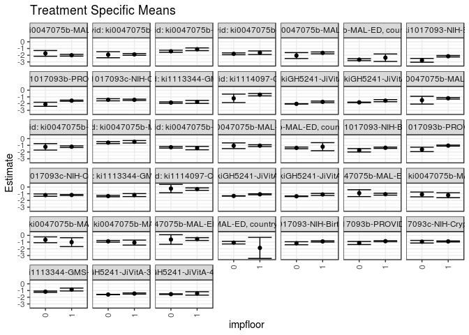

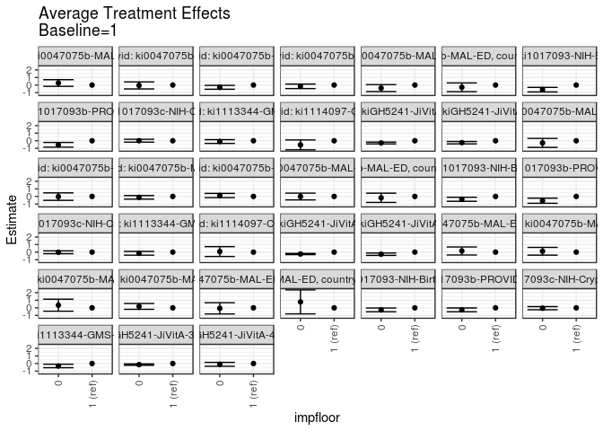

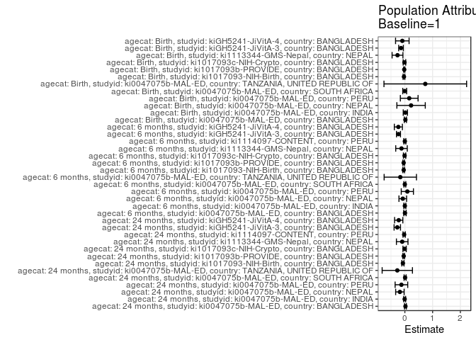

## Results Table

### Parameter: TSM

| agecat | studyid | country | intervention_level | baseline_level | estimate | ci_lower | ci_upper |
| --- | --- | --- | --- | --- | --- | --- | --- |
| Birth | ki0047075b-MAL-ED | BANGLADESH | 1 | NA | -1.0711460 | -1.2137838 | -0.9285083 |
| Birth | ki0047075b-MAL-ED | BANGLADESH | 0 | NA | -0.9158767 | -1.4230643 | -0.4086890 |
| Birth | ki0047075b-MAL-ED | INDIA | 1 | NA | -1.2242857 | -1.5919558 | -0.8566156 |
| Birth | ki0047075b-MAL-ED | INDIA | 0 | NA | -1.1066667 | -1.4622060 | -0.7511274 |
| Birth | ki0047075b-MAL-ED | NEPAL | 1 | NA | -1.0066667 | -1.6704675 | -0.3428658 |
| Birth | ki0047075b-MAL-ED | NEPAL | 0 | NA | -0.6568750 | -1.0897018 | -0.2240482 |
| Birth | ki0047075b-MAL-ED | PERU | 1 | NA | -1.0709304 | -1.4429095 | -0.6989513 |
| Birth | ki0047075b-MAL-ED | PERU | 0 | NA | -0.8802719 | -1.0028852 | -0.7576586 |
| Birth | ki0047075b-MAL-ED | SOUTH AFRICA | 1 | NA | -0.5463218 | -0.7573107 | -0.3353330 |
| Birth | ki0047075b-MAL-ED | SOUTH AFRICA | 0 | NA | -0.6111111 | -1.3247632 | 0.1025410 |
| Birth | ki0047075b-MAL-ED | TANZANIA, UNITED REPUBLIC OF | 1 | NA | -1.8571429 | -3.4252117 | -0.2890740 |
| Birth | ki0047075b-MAL-ED | TANZANIA, UNITED REPUBLIC OF | 0 | NA | -1.0753571 | -1.2760805 | -0.8746338 |
| Birth | ki1017093-NIH-Birth | BANGLADESH | 1 | NA | -0.8965277 | -0.9919541 | -0.8011013 |
| Birth | ki1017093-NIH-Birth | BANGLADESH | 0 | NA | -1.1672951 | -1.3935443 | -0.9410459 |
| Birth | ki1017093b-PROVIDE | BANGLADESH | 1 | NA | -0.8629596 | -0.9419281 | -0.7839911 |
| Birth | ki1017093b-PROVIDE | BANGLADESH | 0 | NA | -1.1292440 | -1.3618779 | -0.8966100 |
| Birth | ki1017093c-NIH-Crypto | BANGLADESH | 1 | NA | -0.8947628 | -0.9735142 | -0.8160115 |
| Birth | ki1017093c-NIH-Crypto | BANGLADESH | 0 | NA | -0.9416333 | -1.1349751 | -0.7482915 |
| Birth | ki1113344-GMS-Nepal | NEPAL | 1 | NA | -0.8528331 | -1.0619941 | -0.6436722 |
| Birth | ki1113344-GMS-Nepal | NEPAL | 0 | NA | -1.1752964 | -1.2759496 | -1.0746431 |
| Birth | kiGH5241-JiVitA-3 | BANGLADESH | 1 | NA | -1.4509526 | -1.5364351 | -1.3654702 |
| Birth | kiGH5241-JiVitA-3 | BANGLADESH | 0 | NA | -1.5939383 | -1.6138141 | -1.5740626 |
| Birth | kiGH5241-JiVitA-4 | BANGLADESH | 1 | NA | -1.4320979 | -1.6857650 | -1.1784307 |
| Birth | kiGH5241-JiVitA-4 | BANGLADESH | 0 | NA | -1.5368987 | -1.5890204 | -1.4847769 |
| 6 months | ki0047075b-MAL-ED | BANGLADESH | 1 | NA | -1.2058786 | -1.3248229 | -1.0869344 |
| 6 months | ki0047075b-MAL-ED | BANGLADESH | 0 | NA | -1.4908155 | -2.0684124 | -0.9132186 |
| 6 months | ki0047075b-MAL-ED | INDIA | 1 | NA | -1.2066675 | -1.3281137 | -1.0852214 |
| 6 months | ki0047075b-MAL-ED | INDIA | 0 | NA | -1.2280898 | -1.7070669 | -0.7491126 |
| 6 months | ki0047075b-MAL-ED | NEPAL | 1 | NA | -0.4783491 | -0.6647671 | -0.2919312 |
| 6 months | ki0047075b-MAL-ED | NEPAL | 0 | NA | -0.5978147 | -0.7429622 | -0.4526673 |
| 6 months | ki0047075b-MAL-ED | PERU | 1 | NA | -1.4141991 | -1.6672866 | -1.1611116 |
| 6 months | ki0047075b-MAL-ED | PERU | 0 | NA | -1.2921079 | -1.4102785 | -1.1739372 |
| 6 months | ki0047075b-MAL-ED | SOUTH AFRICA | 1 | NA | -1.0538321 | -1.1902592 | -0.9174051 |
| 6 months | ki0047075b-MAL-ED | SOUTH AFRICA | 0 | NA | -1.0648093 | -1.4887219 | -0.6408967 |
| 6 months | ki0047075b-MAL-ED | TANZANIA, UNITED REPUBLIC OF | 1 | NA | -1.2057893 | -1.8027698 | -0.6088088 |
| 6 months | ki0047075b-MAL-ED | TANZANIA, UNITED REPUBLIC OF | 0 | NA | -1.3846114 | -1.5115508 | -1.2576721 |
| 6 months | ki1017093-NIH-Birth | BANGLADESH | 1 | NA | -1.3640671 | -1.4579586 | -1.2701756 |
| 6 months | ki1017093-NIH-Birth | BANGLADESH | 0 | NA | -1.7407081 | -1.9907491 | -1.4906671 |
| 6 months | ki1017093b-PROVIDE | BANGLADESH | 1 | NA | -1.0479430 | -1.1228924 | -0.9729937 |
| 6 months | ki1017093b-PROVIDE | BANGLADESH | 0 | NA | -1.6094680 | -1.9375780 | -1.2813580 |
| 6 months | ki1017093c-NIH-Crypto | BANGLADESH | 1 | NA | -1.1890935 | -1.2688228 | -1.1093641 |
| 6 months | ki1017093c-NIH-Crypto | BANGLADESH | 0 | NA | -1.2062010 | -1.3779795 | -1.0344224 |
| 6 months | ki1113344-GMS-Nepal | NEPAL | 1 | NA | -1.2011375 | -1.4228795 | -0.9793956 |
| 6 months | ki1113344-GMS-Nepal | NEPAL | 0 | NA | -1.3518899 | -1.4540979 | -1.2496818 |
| 6 months | ki1114097-CONTENT | PERU | 1 | NA | -0.3132252 | -0.4945470 | -0.1319034 |
| 6 months | ki1114097-CONTENT | PERU | 0 | NA | -0.2356159 | -0.8576103 | 0.3863785 |
| 6 months | kiGH5241-JiVitA-3 | BANGLADESH | 1 | NA | -1.0837090 | -1.1564557 | -1.0109624 |
| 6 months | kiGH5241-JiVitA-3 | BANGLADESH | 0 | NA | -1.3312405 | -1.3550412 | -1.3074399 |
| 6 months | kiGH5241-JiVitA-4 | BANGLADESH | 1 | NA | -1.1097594 | -1.2641380 | -0.9553808 |
| 6 months | kiGH5241-JiVitA-4 | BANGLADESH | 0 | NA | -1.3795404 | -1.4198385 | -1.3392423 |
| 24 months | ki0047075b-MAL-ED | BANGLADESH | 1 | NA | -1.9994869 | -2.1329131 | -1.8660607 |
| 24 months | ki0047075b-MAL-ED | BANGLADESH | 0 | NA | -1.7294691 | -2.1555144 | -1.3034238 |
| 24 months | ki0047075b-MAL-ED | INDIA | 1 | NA | -1.8787099 | -2.0065835 | -1.7508364 |
| 24 months | ki0047075b-MAL-ED | INDIA | 0 | NA | -1.9276237 | -2.3769760 | -1.4782714 |
| 24 months | ki0047075b-MAL-ED | NEPAL | 1 | NA | -1.1136542 | -1.3156087 | -0.9116997 |
| 24 months | ki0047075b-MAL-ED | NEPAL | 0 | NA | -1.4129564 | -1.5666894 | -1.2592234 |
| 24 months | ki0047075b-MAL-ED | PERU | 1 | NA | -1.6284500 | -1.8947715 | -1.3621284 |
| 24 months | ki0047075b-MAL-ED | PERU | 0 | NA | -1.7942951 | -1.9300739 | -1.6585163 |
| 24 months | ki0047075b-MAL-ED | SOUTH AFRICA | 1 | NA | -1.6538151 | -1.7944218 | -1.5132084 |
| 24 months | ki0047075b-MAL-ED | SOUTH AFRICA | 0 | NA | -2.0518567 | -2.4895194 | -1.6141939 |
| 24 months | ki0047075b-MAL-ED | TANZANIA, UNITED REPUBLIC OF | 1 | NA | -2.3707707 | -2.9260363 | -1.8155050 |
| 24 months | ki0047075b-MAL-ED | TANZANIA, UNITED REPUBLIC OF | 0 | NA | -2.6620233 | -2.8027082 | -2.5213384 |
| 24 months | ki1017093-NIH-Birth | BANGLADESH | 1 | NA | -2.1528502 | -2.2607348 | -2.0449656 |
| 24 months | ki1017093-NIH-Birth | BANGLADESH | 0 | NA | -2.7582467 | -3.0405862 | -2.4759073 |
| 24 months | ki1017093b-PROVIDE | BANGLADESH | 1 | NA | -1.5603397 | -1.6454806 | -1.4751987 |
| 24 months | ki1017093b-PROVIDE | BANGLADESH | 0 | NA | -2.0977997 | -2.3989198 | -1.7966795 |
| 24 months | ki1017093c-NIH-Crypto | BANGLADESH | 1 | NA | -1.4319451 | -1.5338773 | -1.3300128 |
| 24 months | ki1017093c-NIH-Crypto | BANGLADESH | 0 | NA | -1.4265180 | -1.5860628 | -1.2669732 |
| 24 months | ki1113344-GMS-Nepal | NEPAL | 1 | NA | -1.7436478 | -1.9645011 | -1.5227945 |
| 24 months | ki1113344-GMS-Nepal | NEPAL | 0 | NA | -1.8469847 | -1.9563908 | -1.7375786 |
| 24 months | ki1114097-CONTENT | PERU | 1 | NA | -0.6704375 | -0.8480453 | -0.4928297 |
| 24 months | ki1114097-CONTENT | PERU | 0 | NA | -1.2143619 | -1.8454797 | -0.5832442 |
| 24 months | kiGH5241-JiVitA-3 | BANGLADESH | 1 | NA | -1.7406710 | -1.8570187 | -1.6243234 |
| 24 months | kiGH5241-JiVitA-3 | BANGLADESH | 0 | NA | -2.0329435 | -2.0617087 | -2.0041783 |
| 24 months | kiGH5241-JiVitA-4 | BANGLADESH | 1 | NA | -1.5590214 | -1.7154261 | -1.4026166 |
| 24 months | kiGH5241-JiVitA-4 | BANGLADESH | 0 | NA | -1.8114603 | -1.8489335 | -1.7739871 |

### Parameter: E(Y)

| agecat | studyid | country | intervention_level | baseline_level | estimate | ci_lower | ci_upper |
| --- | --- | --- | --- | --- | --- | --- | --- |
| Birth | ki0047075b-MAL-ED | BANGLADESH | NA | NA | -1.0530516 | -1.1896058 | -0.9164975 |
| Birth | ki0047075b-MAL-ED | INDIA | NA | NA | -1.2070732 | -1.5254820 | -0.8886644 |
| Birth | ki0047075b-MAL-ED | NEPAL | NA | NA | -0.7828000 | -1.1547571 | -0.4108429 |
| Birth | ki0047075b-MAL-ED | PERU | NA | NA | -0.9141395 | -1.0364098 | -0.7918693 |
| Birth | ki0047075b-MAL-ED | SOUTH AFRICA | NA | NA | -0.5523958 | -0.7550074 | -0.3497843 |
| Birth | ki0047075b-MAL-ED | TANZANIA, UNITED REPUBLIC OF | NA | NA | -1.1213445 | -1.3341800 | -0.9085090 |
| Birth | ki1017093-NIH-Birth | BANGLADESH | NA | NA | -0.9289256 | -1.0178691 | -0.8399821 |
| Birth | ki1017093b-PROVIDE | BANGLADESH | NA | NA | -0.8851020 | -0.9601332 | -0.8100709 |
| Birth | ki1017093c-NIH-Crypto | BANGLADESH | NA | NA | -0.9094945 | -0.9809370 | -0.8380521 |
| Birth | ki1113344-GMS-Nepal | NEPAL | NA | NA | -1.1177022 | -1.2075344 | -1.0278700 |
| Birth | kiGH5241-JiVitA-3 | BANGLADESH | NA | NA | -1.5895451 | -1.6088186 | -1.5702715 |
| Birth | kiGH5241-JiVitA-4 | BANGLADESH | NA | NA | -1.5236135 | -1.5727559 | -1.4744711 |
| 6 months | ki0047075b-MAL-ED | BANGLADESH | NA | NA | -1.2026806 | -1.3203025 | -1.0850586 |
| 6 months | ki0047075b-MAL-ED | INDIA | NA | NA | -1.2070638 | -1.3255909 | -1.0885368 |
| 6 months | ki0047075b-MAL-ED | NEPAL | NA | NA | -0.5534862 | -0.6681825 | -0.4387899 |
| 6 months | ki0047075b-MAL-ED | PERU | NA | NA | -1.3248549 | -1.4336721 | -1.2160378 |
| 6 months | ki0047075b-MAL-ED | SOUTH AFRICA | NA | NA | -1.0547925 | -1.1843544 | -0.9252306 |
| 6 months | ki0047075b-MAL-ED | TANZANIA, UNITED REPUBLIC OF | NA | NA | -1.3700408 | -1.4930436 | -1.2470380 |
| 6 months | ki1017093-NIH-Birth | BANGLADESH | NA | NA | -1.4060639 | -1.4948910 | -1.3172368 |
| 6 months | ki1017093b-PROVIDE | BANGLADESH | NA | NA | -1.0916915 | -1.1661176 | -1.0172654 |
| 6 months | ki1017093c-NIH-Crypto | BANGLADESH | NA | NA | -1.1986783 | -1.2700937 | -1.1272630 |
| 6 months | ki1113344-GMS-Nepal | NEPAL | NA | NA | -1.3225094 | -1.4115793 | -1.2334396 |
| 6 months | ki1114097-CONTENT | PERU | NA | NA | -0.3139217 | -0.4868486 | -0.1409948 |
| 6 months | kiGH5241-JiVitA-3 | BANGLADESH | NA | NA | -1.3134597 | -1.3365976 | -1.2903219 |
| 6 months | kiGH5241-JiVitA-4 | BANGLADESH | NA | NA | -1.3440174 | -1.3812821 | -1.3067527 |
| 24 months | ki0047075b-MAL-ED | BANGLADESH | NA | NA | -1.9783962 | -2.1050210 | -1.8517715 |
| 24 months | ki0047075b-MAL-ED | INDIA | NA | NA | -1.8861894 | -2.0110006 | -1.7613783 |
| 24 months | ki0047075b-MAL-ED | NEPAL | NA | NA | -1.2928054 | -1.4146944 | -1.1709164 |
| 24 months | ki0047075b-MAL-ED | PERU | NA | NA | -1.7524710 | -1.8736426 | -1.6312994 |
| 24 months | ki0047075b-MAL-ED | SOUTH AFRICA | NA | NA | -1.6450595 | -1.7797240 | -1.5103950 |
| 24 months | ki0047075b-MAL-ED | TANZANIA, UNITED REPUBLIC OF | NA | NA | -2.6432311 | -2.7795797 | -2.5068826 |
| 24 months | ki1017093-NIH-Birth | BANGLADESH | NA | NA | -2.2235968 | -2.3265592 | -2.1206344 |
| 24 months | ki1017093b-PROVIDE | BANGLADESH | NA | NA | -1.6024221 | -1.6857420 | -1.5191023 |
| 24 months | ki1017093c-NIH-Crypto | BANGLADESH | NA | NA | -1.4412646 | -1.5249156 | -1.3576135 |
| 24 months | ki1113344-GMS-Nepal | NEPAL | NA | NA | -1.8396747 | -1.9349390 | -1.7444104 |
| 24 months | ki1114097-CONTENT | PERU | NA | NA | -0.6962195 | -0.8674103 | -0.5250287 |
| 24 months | kiGH5241-JiVitA-3 | BANGLADESH | NA | NA | -2.0134592 | -2.0410825 | -1.9858359 |
| 24 months | kiGH5241-JiVitA-4 | BANGLADESH | NA | NA | -1.7804046 | -1.8159135 | -1.7448956 |

### Parameter: ATE

| agecat | studyid | country | intervention_level | baseline_level | estimate | ci_lower | ci_upper |
| --- | --- | --- | --- | --- | --- | --- | --- |
| Birth | ki0047075b-MAL-ED | BANGLADESH | 1 | 1 | 0.0000000 | 0.0000000 | 0.0000000 |
| Birth | ki0047075b-MAL-ED | BANGLADESH | 0 | 1 | 0.1552694 | -0.3723761 | 0.6829148 |
| Birth | ki0047075b-MAL-ED | INDIA | 1 | 1 | 0.0000000 | 0.0000000 | 0.0000000 |
| Birth | ki0047075b-MAL-ED | INDIA | 0 | 1 | 0.1176190 | -0.3938392 | 0.6290772 |
| Birth | ki0047075b-MAL-ED | NEPAL | 1 | 1 | 0.0000000 | 0.0000000 | 0.0000000 |
| Birth | ki0047075b-MAL-ED | NEPAL | 0 | 1 | 0.3497917 | -0.4426543 | 1.1422376 |
| Birth | ki0047075b-MAL-ED | PERU | 1 | 1 | 0.0000000 | 0.0000000 | 0.0000000 |
| Birth | ki0047075b-MAL-ED | PERU | 0 | 1 | 0.1906585 | -0.1982368 | 0.5795538 |
| Birth | ki0047075b-MAL-ED | SOUTH AFRICA | 1 | 1 | 0.0000000 | 0.0000000 | 0.0000000 |
| Birth | ki0047075b-MAL-ED | SOUTH AFRICA | 0 | 1 | -0.0647893 | -0.8089772 | 0.6793986 |
| Birth | ki0047075b-MAL-ED | TANZANIA, UNITED REPUBLIC OF | 1 | 1 | 0.0000000 | 0.0000000 | 0.0000000 |
| Birth | ki0047075b-MAL-ED | TANZANIA, UNITED REPUBLIC OF | 0 | 1 | 0.7817857 | -0.7990779 | 2.3626493 |
| Birth | ki1017093-NIH-Birth | BANGLADESH | 1 | 1 | 0.0000000 | 0.0000000 | 0.0000000 |
| Birth | ki1017093-NIH-Birth | BANGLADESH | 0 | 1 | -0.2707675 | -0.5162379 | -0.0252970 |
| Birth | ki1017093b-PROVIDE | BANGLADESH | 1 | 1 | 0.0000000 | 0.0000000 | 0.0000000 |
| Birth | ki1017093b-PROVIDE | BANGLADESH | 0 | 1 | -0.2662844 | -0.5115309 | -0.0210378 |
| Birth | ki1017093c-NIH-Crypto | BANGLADESH | 1 | 1 | 0.0000000 | 0.0000000 | 0.0000000 |
| Birth | ki1017093c-NIH-Crypto | BANGLADESH | 0 | 1 | -0.0468705 | -0.2552551 | 0.1615142 |
| Birth | ki1113344-GMS-Nepal | NEPAL | 1 | 1 | 0.0000000 | 0.0000000 | 0.0000000 |
| Birth | ki1113344-GMS-Nepal | NEPAL | 0 | 1 | -0.3224632 | -0.5547156 | -0.0902108 |
| Birth | kiGH5241-JiVitA-3 | BANGLADESH | 1 | 1 | 0.0000000 | 0.0000000 | 0.0000000 |
| Birth | kiGH5241-JiVitA-3 | BANGLADESH | 0 | 1 | -0.1429857 | -0.2295288 | -0.0564426 |
| Birth | kiGH5241-JiVitA-4 | BANGLADESH | 1 | 1 | 0.0000000 | 0.0000000 | 0.0000000 |
| Birth | kiGH5241-JiVitA-4 | BANGLADESH | 0 | 1 | -0.1048008 | -0.3631099 | 0.1535084 |
| 6 months | ki0047075b-MAL-ED | BANGLADESH | 1 | 1 | 0.0000000 | 0.0000000 | 0.0000000 |
| 6 months | ki0047075b-MAL-ED | BANGLADESH | 0 | 1 | -0.2849369 | -0.8753018 | 0.3054280 |
| 6 months | ki0047075b-MAL-ED | INDIA | 1 | 1 | 0.0000000 | 0.0000000 | 0.0000000 |
| 6 months | ki0047075b-MAL-ED | INDIA | 0 | 1 | -0.0214222 | -0.5155610 | 0.4727165 |
| 6 months | ki0047075b-MAL-ED | NEPAL | 1 | 1 | 0.0000000 | 0.0000000 | 0.0000000 |
| 6 months | ki0047075b-MAL-ED | NEPAL | 0 | 1 | -0.1194656 | -0.3562176 | 0.1172864 |
| 6 months | ki0047075b-MAL-ED | PERU | 1 | 1 | 0.0000000 | 0.0000000 | 0.0000000 |
| 6 months | ki0047075b-MAL-ED | PERU | 0 | 1 | 0.1220913 | -0.1577142 | 0.4018967 |
| 6 months | ki0047075b-MAL-ED | SOUTH AFRICA | 1 | 1 | 0.0000000 | 0.0000000 | 0.0000000 |
| 6 months | ki0047075b-MAL-ED | SOUTH AFRICA | 0 | 1 | -0.0109772 | -0.4564664 | 0.4345121 |
| 6 months | ki0047075b-MAL-ED | TANZANIA, UNITED REPUBLIC OF | 1 | 1 | 0.0000000 | 0.0000000 | 0.0000000 |
| 6 months | ki0047075b-MAL-ED | TANZANIA, UNITED REPUBLIC OF | 0 | 1 | -0.1788221 | -0.7895397 | 0.4318954 |
| 6 months | ki1017093-NIH-Birth | BANGLADESH | 1 | 1 | 0.0000000 | 0.0000000 | 0.0000000 |
| 6 months | ki1017093-NIH-Birth | BANGLADESH | 0 | 1 | -0.3766410 | -0.6432036 | -0.1100783 |
| 6 months | ki1017093b-PROVIDE | BANGLADESH | 1 | 1 | 0.0000000 | 0.0000000 | 0.0000000 |
| 6 months | ki1017093b-PROVIDE | BANGLADESH | 0 | 1 | -0.5615249 | -0.8981623 | -0.2248876 |
| 6 months | ki1017093c-NIH-Crypto | BANGLADESH | 1 | 1 | 0.0000000 | 0.0000000 | 0.0000000 |
| 6 months | ki1017093c-NIH-Crypto | BANGLADESH | 0 | 1 | -0.0171075 | -0.2053241 | 0.1711092 |
| 6 months | ki1113344-GMS-Nepal | NEPAL | 1 | 1 | 0.0000000 | 0.0000000 | 0.0000000 |
| 6 months | ki1113344-GMS-Nepal | NEPAL | 0 | 1 | -0.1507523 | -0.3976618 | 0.0961572 |
| 6 months | ki1114097-CONTENT | PERU | 1 | 1 | 0.0000000 | 0.0000000 | 0.0000000 |
| 6 months | ki1114097-CONTENT | PERU | 0 | 1 | 0.0776093 | -0.5717945 | 0.7270131 |
| 6 months | kiGH5241-JiVitA-3 | BANGLADESH | 1 | 1 | 0.0000000 | 0.0000000 | 0.0000000 |
| 6 months | kiGH5241-JiVitA-3 | BANGLADESH | 0 | 1 | -0.2475315 | -0.3225970 | -0.1724660 |
| 6 months | kiGH5241-JiVitA-4 | BANGLADESH | 1 | 1 | 0.0000000 | 0.0000000 | 0.0000000 |
| 6 months | kiGH5241-JiVitA-4 | BANGLADESH | 0 | 1 | -0.2697810 | -0.4256424 | -0.1139197 |
| 24 months | ki0047075b-MAL-ED | BANGLADESH | 1 | 1 | 0.0000000 | 0.0000000 | 0.0000000 |
| 24 months | ki0047075b-MAL-ED | BANGLADESH | 0 | 1 | 0.2700178 | -0.1723463 | 0.7123818 |
| 24 months | ki0047075b-MAL-ED | INDIA | 1 | 1 | 0.0000000 | 0.0000000 | 0.0000000 |
| 24 months | ki0047075b-MAL-ED | INDIA | 0 | 1 | -0.0489137 | -0.5141747 | 0.4163472 |
| 24 months | ki0047075b-MAL-ED | NEPAL | 1 | 1 | 0.0000000 | 0.0000000 | 0.0000000 |
| 24 months | ki0047075b-MAL-ED | NEPAL | 0 | 1 | -0.2993022 | -0.5543642 | -0.0442403 |
| 24 months | ki0047075b-MAL-ED | PERU | 1 | 1 | 0.0000000 | 0.0000000 | 0.0000000 |
| 24 months | ki0047075b-MAL-ED | PERU | 0 | 1 | -0.1658451 | -0.4646122 | 0.1329219 |
| 24 months | ki0047075b-MAL-ED | SOUTH AFRICA | 1 | 1 | 0.0000000 | 0.0000000 | 0.0000000 |
| 24 months | ki0047075b-MAL-ED | SOUTH AFRICA | 0 | 1 | -0.3980415 | -0.8574942 | 0.0614111 |
| 24 months | ki0047075b-MAL-ED | TANZANIA, UNITED REPUBLIC OF | 1 | 1 | 0.0000000 | 0.0000000 | 0.0000000 |
| 24 months | ki0047075b-MAL-ED | TANZANIA, UNITED REPUBLIC OF | 0 | 1 | -0.2912526 | -0.8637712 | 0.2812659 |
| 24 months | ki1017093-NIH-Birth | BANGLADESH | 1 | 1 | 0.0000000 | 0.0000000 | 0.0000000 |
| 24 months | ki1017093-NIH-Birth | BANGLADESH | 0 | 1 | -0.6053965 | -0.9063252 | -0.3044679 |
| 24 months | ki1017093b-PROVIDE | BANGLADESH | 1 | 1 | 0.0000000 | 0.0000000 | 0.0000000 |
| 24 months | ki1017093b-PROVIDE | BANGLADESH | 0 | 1 | -0.5374600 | -0.8499039 | -0.2250160 |
| 24 months | ki1017093c-NIH-Crypto | BANGLADESH | 1 | 1 | 0.0000000 | 0.0000000 | 0.0000000 |
| 24 months | ki1017093c-NIH-Crypto | BANGLADESH | 0 | 1 | 0.0054271 | -0.1840355 | 0.1948896 |
| 24 months | ki1113344-GMS-Nepal | NEPAL | 1 | 1 | 0.0000000 | 0.0000000 | 0.0000000 |
| 24 months | ki1113344-GMS-Nepal | NEPAL | 0 | 1 | -0.1033369 | -0.3508828 | 0.1442090 |
| 24 months | ki1114097-CONTENT | PERU | 1 | 1 | 0.0000000 | 0.0000000 | 0.0000000 |
| 24 months | ki1114097-CONTENT | PERU | 0 | 1 | -0.5439244 | -1.1987542 | 0.1109054 |
| 24 months | kiGH5241-JiVitA-3 | BANGLADESH | 1 | 1 | 0.0000000 | 0.0000000 | 0.0000000 |
| 24 months | kiGH5241-JiVitA-3 | BANGLADESH | 0 | 1 | -0.2922725 | -0.4118218 | -0.1727231 |
| 24 months | kiGH5241-JiVitA-4 | BANGLADESH | 1 | 1 | 0.0000000 | 0.0000000 | 0.0000000 |
| 24 months | kiGH5241-JiVitA-4 | BANGLADESH | 0 | 1 | -0.2524389 | -0.4105388 | -0.0943390 |

### Parameter: PAR

| agecat | studyid | country | intervention_level | baseline_level | estimate | ci_lower | ci_upper |
| --- | --- | --- | --- | --- | --- | --- | --- |
| Birth | ki0047075b-MAL-ED | BANGLADESH | 1 | NA | 0.0180944 | -0.0215435 | 0.0577323 |
| Birth | ki0047075b-MAL-ED | INDIA | 1 | NA | 0.0172125 | -0.0587357 | 0.0931607 |
| Birth | ki0047075b-MAL-ED | NEPAL | 1 | NA | 0.2238667 | -0.2877278 | 0.7354611 |
| Birth | ki0047075b-MAL-ED | PERU | 1 | NA | 0.1567909 | -0.1620996 | 0.4756813 |
| Birth | ki0047075b-MAL-ED | SOUTH AFRICA | 1 | NA | -0.0060740 | -0.0759449 | 0.0637969 |
| Birth | ki0047075b-MAL-ED | TANZANIA, UNITED REPUBLIC OF | 1 | NA | 0.7357983 | -0.7524434 | 2.2240401 |
| Birth | ki1017093-NIH-Birth | BANGLADESH | 1 | NA | -0.0323980 | -0.0629884 | -0.0018075 |
| Birth | ki1017093b-PROVIDE | BANGLADESH | 1 | NA | -0.0221425 | -0.0442528 | -0.0000321 |
| Birth | ki1017093c-NIH-Crypto | BANGLADESH | 1 | NA | -0.0147317 | -0.0611094 | 0.0316460 |
| Birth | ki1113344-GMS-Nepal | NEPAL | 1 | NA | -0.2648691 | -0.4601504 | -0.0695877 |
| Birth | kiGH5241-JiVitA-3 | BANGLADESH | 1 | NA | -0.1385924 | -0.2223093 | -0.0548755 |
| Birth | kiGH5241-JiVitA-4 | BANGLADESH | 1 | NA | -0.0915156 | -0.3350806 | 0.1520494 |
| 6 months | ki0047075b-MAL-ED | BANGLADESH | 1 | NA | 0.0031981 | -0.0412062 | 0.0476023 |
| 6 months | ki0047075b-MAL-ED | INDIA | 1 | NA | -0.0003963 | -0.0363310 | 0.0355384 |
| 6 months | ki0047075b-MAL-ED | NEPAL | 1 | NA | -0.0751370 | -0.2124279 | 0.0621538 |
| 6 months | ki0047075b-MAL-ED | PERU | 1 | NA | 0.0893442 | -0.1302524 | 0.3089407 |
| 6 months | ki0047075b-MAL-ED | SOUTH AFRICA | 1 | NA | -0.0009604 | -0.0354180 | 0.0334973 |
| 6 months | ki0047075b-MAL-ED | TANZANIA, UNITED REPUBLIC OF | 1 | NA | -0.1642515 | -0.7464001 | 0.4178970 |
| 6 months | ki1017093-NIH-Birth | BANGLADESH | 1 | NA | -0.0419968 | -0.0720932 | -0.0119003 |
| 6 months | ki1017093b-PROVIDE | BANGLADESH | 1 | NA | -0.0437485 | -0.0721697 | -0.0153272 |
| 6 months | ki1017093c-NIH-Crypto | BANGLADESH | 1 | NA | -0.0095848 | -0.0520598 | 0.0328901 |
| 6 months | ki1113344-GMS-Nepal | NEPAL | 1 | NA | -0.1213719 | -0.3291177 | 0.0863739 |
| 6 months | ki1114097-CONTENT | PERU | 1 | NA | -0.0006965 | -0.0375287 | 0.0361356 |
| 6 months | kiGH5241-JiVitA-3 | BANGLADESH | 1 | NA | -0.2297507 | -0.3016436 | -0.1578578 |
| 6 months | kiGH5241-JiVitA-4 | BANGLADESH | 1 | NA | -0.2342580 | -0.3795186 | -0.0889974 |
| 24 months | ki0047075b-MAL-ED | BANGLADESH | 1 | NA | 0.0210906 | -0.0113975 | 0.0535788 |
| 24 months | ki0047075b-MAL-ED | INDIA | 1 | NA | -0.0074795 | -0.0425630 | 0.0276040 |
| 24 months | ki0047075b-MAL-ED | NEPAL | 1 | NA | -0.1791512 | -0.3311743 | -0.0271282 |
| 24 months | ki0047075b-MAL-ED | PERU | 1 | NA | -0.1240210 | -0.3509005 | 0.1028584 |
| 24 months | ki0047075b-MAL-ED | SOUTH AFRICA | 1 | NA | 0.0087556 | -0.0288201 | 0.0463313 |
| 24 months | ki0047075b-MAL-ED | TANZANIA, UNITED REPUBLIC OF | 1 | NA | -0.2724605 | -0.8183570 | 0.2734361 |
| 24 months | ki1017093-NIH-Birth | BANGLADESH | 1 | NA | -0.0707466 | -0.1099731 | -0.0315201 |
| 24 months | ki1017093b-PROVIDE | BANGLADESH | 1 | NA | -0.0420825 | -0.0697529 | -0.0144120 |
| 24 months | ki1017093c-NIH-Crypto | BANGLADESH | 1 | NA | -0.0093195 | -0.0686706 | 0.0500315 |
| 24 months | ki1113344-GMS-Nepal | NEPAL | 1 | NA | -0.0960269 | -0.3040942 | 0.1120405 |
| 24 months | ki1114097-CONTENT | PERU | 1 | NA | -0.0257820 | -0.0662563 | 0.0146924 |
| 24 months | kiGH5241-JiVitA-3 | BANGLADESH | 1 | NA | -0.2727881 | -0.3879432 | -0.1576331 |
| 24 months | kiGH5241-JiVitA-4 | BANGLADESH | 1 | NA | -0.2213832 | -0.3699159 | -0.0728504 |